# 8. Random, Aggregated, and Regular Patterns

# First Order Intensity

For the process $Y(u)$ we assume that $E[Y(u)] = \mu(u)$, that is, the expectation depends on the location. It is often assumed, however, that $\mu(u) = \mu$, a constant expectation over the area. This should be tested of course.

The intensity (first-order) $\mu(s)$ is the average number of events per unit area.

$$\mu(s) = \lim_{\nu(ds) \to 0}
\frac{E[N(ds)]}{\nu(ds)}$$
where $ds$ is an infinitesimal area (disc) in $\mathbb{R}^d$ centered at $s$.

# First Order Intensity

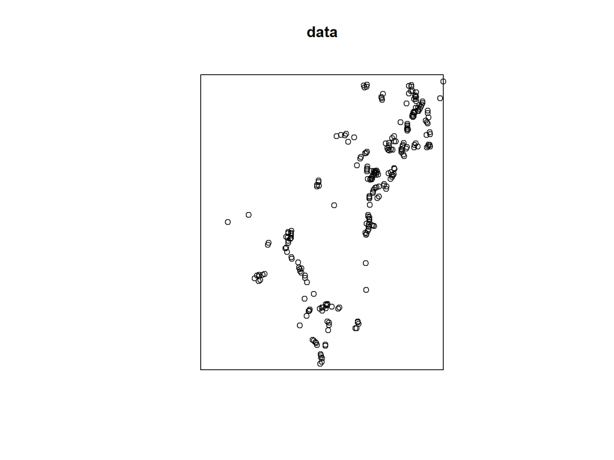

```r
data(murchison)
data <- murchison$gold
plot(data)
```

# First Order Intensity

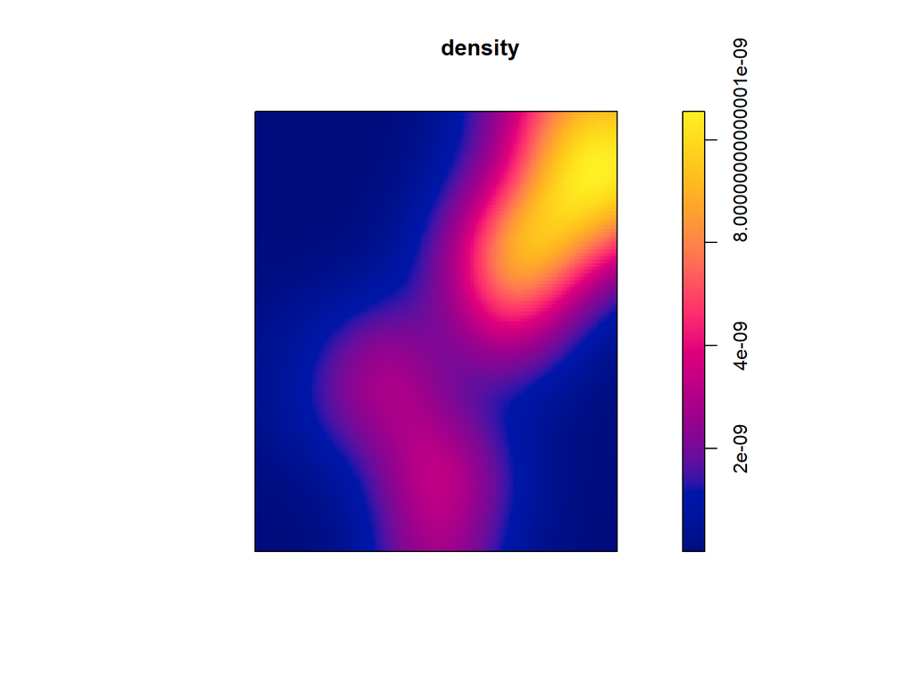

```r
plot(density.ppp(data), main = "density")
```

# Three types of stationarity:

1. STRICT STATIONARITY:
   $$\forall
   h~P[Y(u_1), Y(u_2),...,Y(u_n)]$$
   $$=
   P[Y(u_1+h), Y(u_2+h),...,Y(u_n+h)].$$

# Three types of stationarity:

2. SECOND ORDER STATIONARITY:
   $$E[Y(u)] =
   \mu \textrm{ and } E(Y(u_i), Y(u_j)) = C(u_i-u_j).$$

Recall: $cov(X,Y) = E[XY] - E[X]E[Y]$ so $cov(Y(u_i),Y(u_j)) = E[Y(u_i)Y(u_j)] - E[Y(u_i)]E[Y(u_j)] = E[Y(u_i)Y(u_j)] - \mu^2$

# Three types of stationarity:

3. INTRINSIC STATIONARITY:
   $$E[Y(u_i)-Y(u_j)] = 0 \textrm{ and }
   E[(Y(u_i)-Y(u_j))^2] = 2\gamma(u_1-u_2).$$

Recall: $cov(X,Y) = E[XY] - E[X]E[Y]$ so $cov(Y(u_i),Y(u_j)) = E[Y(u_i)Y(u_j)] - E[Y(u_i)]E[Y(u_j)] = [Y(u_i)Y(u_j)] - \mu^2$

# ERGODIC PROCESS:

Has the same behaviour averaged over space as averaged over the space of all the system’s states, so that we can use the spatially shifted data to estimate the properties locally.

# ISOTROPIC PROCESS:

A process is isotropic if the variation (the covariance function) is the same in every *direction*. Otherwise the process is called anisotropic, depending on both the length and direction of the distance vector $u_i - u_j$.

```r
angles <- nnorient(murchison$gold, correction = "none")
r <- rose(angles)
```

[figure not shown]

# Random process: homogeneous Poisson process

A *homogeneous Poisson process* is a model for a discrete events in space where the expected distance between events is known, but the exact locations is random. Usually indicated with a parameter $\lambda$ which gives the expected number of events in a unit area.

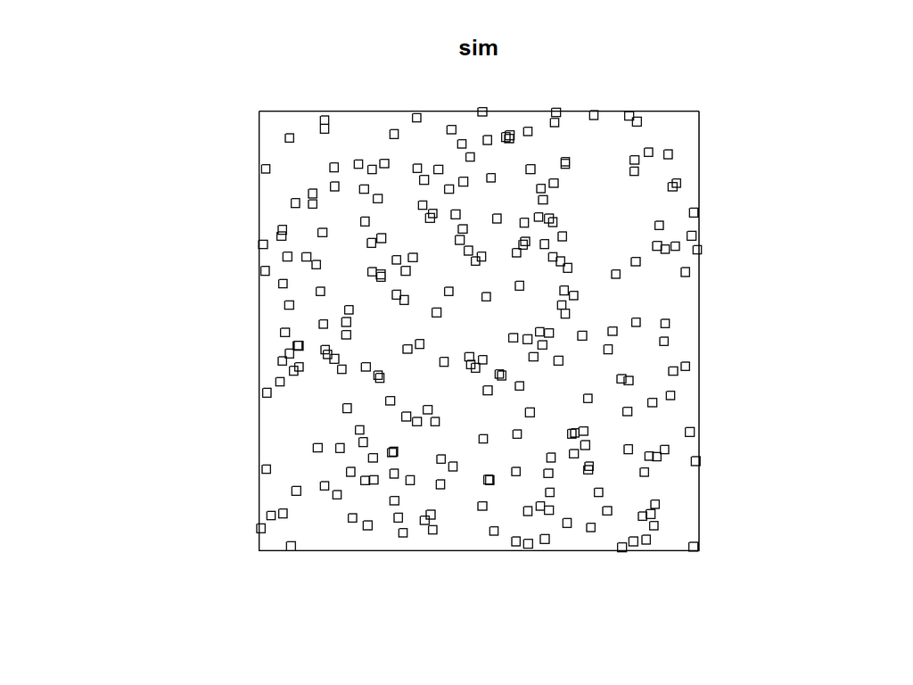

```r
sim <- rpoispp(lambda = 200)
plot(sim, pch = 0.1)
```